# Question 1: Insights into the Covid 19 pandemic

Abstract

An analysis of the effects of Covid 19 follows. It was found that Africa had lower vaccination rates and an accompanying higher death rate relative to infection rates than the rest of the world. Further it was found that higher rates of smoking had a high correlation (~30%) with ICU admission rates and by extension, death rates. Finally, it was found that no single country managed to increase the number of hospital beds during the pandemic - or rather, it was found that the data may have some mistakes in it.

The number of vaccines administered to Africa has been significantly lower than what the rest of the world receievd. This has been widely attributed to vaccine hoarding by richer countries as well as vaccine hesitancy prevelant amongst African communities.

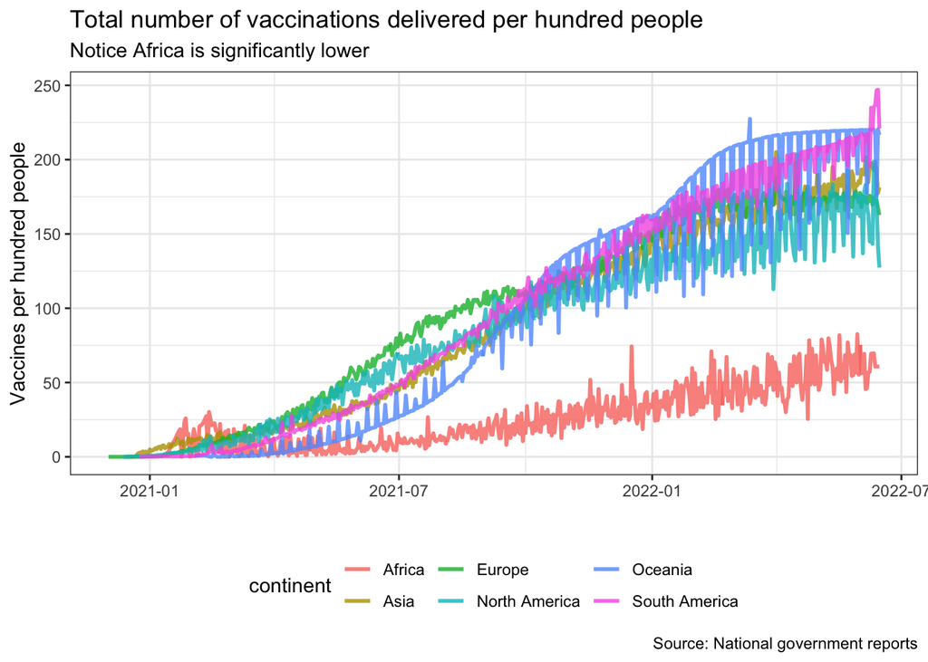

Covid Vaccines.

The number of deaths relative to the number of cases is higher in Africa than it is in non-Africa, this is demonstrated in the graphs below.

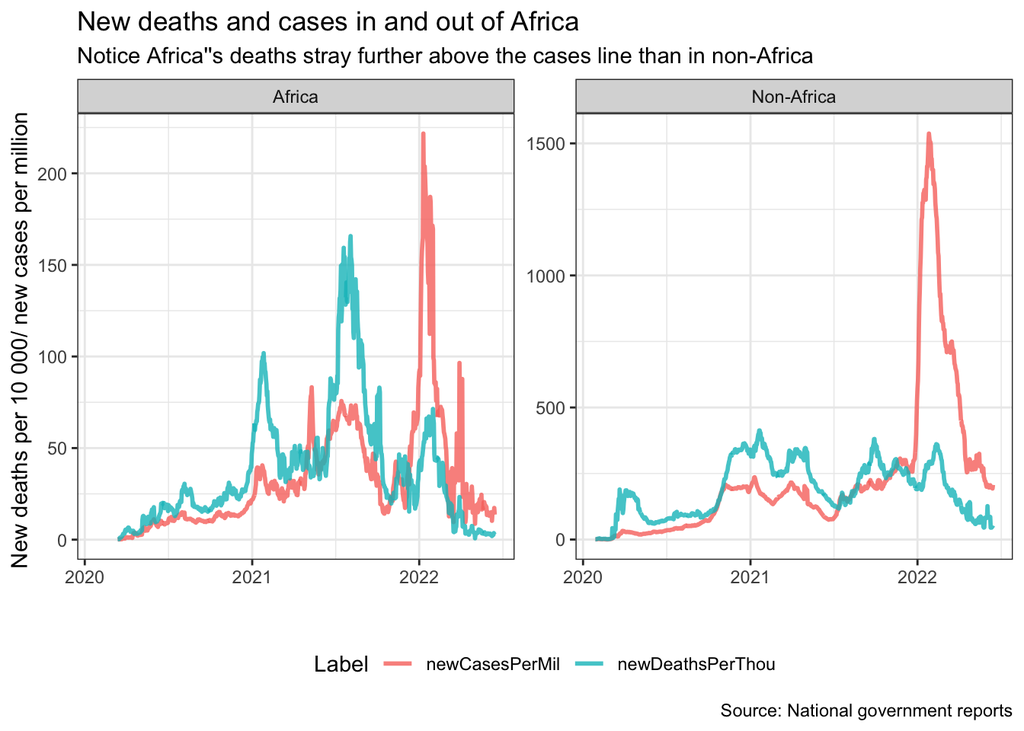

Covid Deaths and Cases.

Regressing the number of deaths per million on the number of icu admissions per million reveals, as expected, that there is a high correlation between ICU admissions and deaths. This was done for countries with smoking data available.

|  | Death_on_ICU |
| --- | --- |
| Dependent Var.: | totalDeathsPerMil |
| (Intercept) | 568.5* (216.9) |
| icuPerMil | 19.32*** (2.510) |
| _______________ | _________________ |
| S.E. type | IID |
| Observations | 38 |
| R2 | 0.62215 |
| Adj. R2 | 0.61165 |

Regressing the rate of ICU admissions on the number of female and male smokers, seperately, reveals that the rate of female smokers is a better and stronger predictor for the rate of ICU admissions.

|  | ICU_on_female |
| --- | --- |
| Dependent Var.: | icuPerMil |
| (Intercept) | 10.90 (16.80) |
| female_smokers | 3.156*** (0.7690) |
| _______________ | _________________ |
| S.E. type | IID |
| Observations | 37 |
| R2 | 0.32494 |
| Adj. R2 | 0.30565 |

|  | ICU_on_male |
| --- | --- |
| Dependent Var.: | icuPerMil |
| (Intercept) | 17.73 (26.30) |
| male_smokers | 1.809* (0.8019) |
| _______________ | _______________ |
| S.E. type | IID |
| Observations | 37 |
| R2 | 0.12693 |
| Adj. R2 | 0.10199 |

Finally, regressing the rate of ICU admissions on the (evenly weighted) average rate of smokers reveals the highest correlation and the highest adjusted r-squared at a 99,9% significance level. Thus it can be said that countries with higher rates of smokers experienced increased rates of admission to ICU wards and by extension rates of death.

|  | ICU_on_mean |
| --- | --- |
| Dependent Var.: | icuPerMil |
| (Intercept) | -25.81 (24.70) |
| meanSmokers | 3.885*** (0.9226) |
| _______________ | _________________ |
| S.E. type | IID |
| Observations | 37 |
| R2 | 0.33630 |
| Adj. R2 | 0.31734 |

The following graphs compare the rate of increase in hospital facilities with the number of icu patients per million. The global quartiles for the mean rate of hospital beds per million over time were taken and countries were divided into the four quartiles. The highest, middle and lowest 2 countries in terms quartile placement were examined for even distribution. However, this was only done for countries with data recorded in the icu admissions rate variable. According to the data the change in the number of hospital beds per thousand people is exactly zero or Na for every country indicating that no new beds were added. As such the analysis was uninteresting. However, the graphs are presented below.

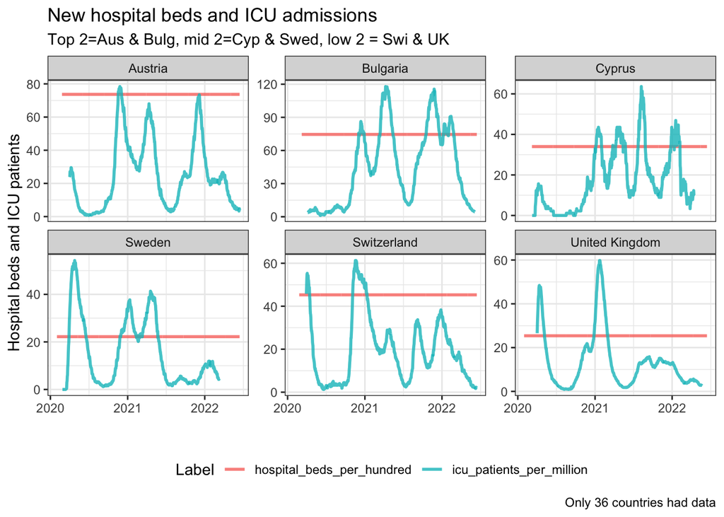

Hospital capacity.

Here is table depicting the change in hospital beds: This is also the end of the document so there isn’t much need to scroll to the bottom of this empty table.

| location | change |
| --- | --- |
| Afghanistan | 0 |
| Africa | NA |
| Albania | 0 |
| Algeria | 0 |
| Andorra | NA |
| Angola | NA |
| Anguilla | NA |
| Antigua and Barbuda | 0 |
| Argentina | 0 |
| Armenia | 0 |
| Aruba | NA |
| Asia | NA |
| Australia | 0 |
| Austria | 0 |
| Azerbaijan | 0 |
| Bahamas | 0 |
| Bahrain | 0 |
| Bangladesh | 0 |
| Barbados | 0 |
| Belarus | 0 |
| Belgium | 0 |
| Belize | 0 |
| Benin | 0 |
| Bermuda | NA |
| Bhutan | 0 |
| Bolivia | 0 |
| Bonaire Sint Eustatius and Saba | NA |
| Bosnia and Herzegovina | 0 |
| Botswana | 0 |
| Brazil | 0 |

[output cut: 214 more lines]

[^1]: **Contributions:** *The authors would like to thank the Kommetjie municipality for today’s water outage. Thank you sincerely.*